# Exploring Factors associated With Diarrhoea Cases in Malawi

Findings from 2018 Malawi Demographics and Health Survery

Joseph Gama Kenneth

2023-12-10

## Demographic and Health Survey (DHS) data

The Demographic and Health Surveys (DHS) are a series of standardized surveys conducted periodically in developing countries that collect data on various aspects of population, health, and nutrition. Demographic and Health Surveys (DHS) are nationally-representative household surveys that provide data for a wide range of monitoring and impact evaluation indicators in the areas of population, health, and nutrition.This analysis looks at Diarrhea cases distribution in Malawi and its associated factors. it trys to look at the how the hypothesized diarrhea causes are are fairing through data visualization.

## Import dataset with **haven** functions

DHS data comes in the form of a **.DTA file** (STATA format) and is loaded in **R** using the *haven* package. When loading the *haven* package, other packages that will be used throughout the analysis are also loaded. These packages include *tidyverse*, *janitor*, *here*, *Paletteer* just to mention a few.

## Importing dataset

Data is imported by selecting all the needed columns by using the col_select function since the DHS data set is very huge and it can take alot of time to load all the columns. then we view the data if all the needed variables are in the environment before performing any task.

## Data Cleaning/Wrangling

### 1. Renaming data variables.

Its great practice to rename the variables in such a way that we are able to know what data they are representing. for example in the DHS dataset, one variable is given as v130. by looking at it, you can not be able to tell that it is religion and thus its difficult to perform any data analysis if you dont know the variables you are dealing with.

### 2. Data types review

using glimpse functions, we can be able to have a look at the data type for each variable. this is good because it helps to inform if some data types need to be changed to allow smooth data analysis

```
## Rows: 24,562
## Columns: 15
## $ age_group             <dbl+lbl> 4, 4, 3, 4, 1, 5, 2, 2, 3, 3, 2, 4, 3, 3, 1,…
## $ region                <dbl+lbl> 2, 2, 2, 2, 2, 2, 2, 2, 2, 2, 2, 2, 2, 2, 2,…
## $ urban_rural           <dbl+lbl> 1, 1, 1, 1, 1, 1, 1, 1, 1, 1, 1, 1, 1, 1, 1,…
## $ highest_educ          <dbl+lbl> 2, 1, 1, 2, 2, 2, 2, 2, 2, 2, 1, 1, 3, 1, 1,…
## $ drinking_water_source <dbl+lbl> 13, 12, 12, 32, 32, 14, 12, 12, 21, 12, 12, …
## $ type_of_toilet        <dbl+lbl> 22, 22, 22, 22, 22, 23, 22, 22, 22, 22, 22, …
## $ religion              <dbl+lbl> 2, 2, 5, 1, 5, 5, 2, 2, 5, 2, 1, 2, 2, 4, 4,…
## $ hhsize                <dbl> 3, 7, 5, 6, 6, 2, 4, 3, 6, 5, 3, 8, 5, 6, 6, 4, …
## $ head_hh_sex           <dbl+lbl> 1, 1, 1, 2, 2, 2, 1, 1, 1, 1, 1, 1, 1, 1, 1,…
## $ headhh_age            <dbl+lbl> 36, 49, 40, 67, 67, 36, 27, 27, 29, 98, 30, …
## $ toilet_shared         <dbl+lbl> 0, 0, 1, 0, 0, 0, 1, 0, 0, 0, 0, 0, 0, 0, 0,…
## $ wealth_index          <dbl+lbl> 5, 5, 5, 4, 4, 3, 5, 5, 5, 5, 5, 5, 5, 2, 2,…
## $ stool_disposal        <dbl+lbl> NA,  2, NA, NA, NA, NA, NA,  2, NA, NA, NA, …
## $ had_diarrhea          <dbl+lbl>  0,  0,  0, NA, NA,  0, NA,  0, NA, NA,  0, …
## $ no_treatment          <dbl+lbl> NA, NA, NA, NA, NA, NA, NA, NA, NA, NA, NA, …
```

looking at the data types above, we see that we need to change them to regular factors data type.

### 3. convert from labelled data to regular factors

using as.factor function available in the *haven* package, we can be able to change the variables to factor as shown below.

```
## Rows: 24,562
## Columns: 15
## $ age_group             <fct> 30-34, 30-34, 25-29, 30-34, 15-19, 35-39, 20-24,…
## $ region                <fct> central region, central region, central region, …
## $ urban_rural           <fct> urban, urban, urban, urban, urban, urban, urban,…
## $ highest_educ          <fct> secondary, primary, primary, secondary, secondar…
## $ drinking_water_source <fct> piped to neighbor, piped to yard/plot, piped to …
## $ type_of_toilet        <fct> "pit latrine with slab", "pit latrine with slab"…
## $ religion              <fct> ccap, ccap, other christian, catholic, other chr…
## $ hhsize                <dbl> 3, 7, 5, 6, 6, 2, 4, 3, 6, 5, 3, 8, 5, 6, 6, 4, …
## $ head_hh_sex           <fct> male, male, male, female, female, female, male, …
## $ headhh_age            <fct> 36, 49, 40, 67, 67, 36, 27, 27, 29, don't know, …
## $ toilet_shared         <fct> no, no, yes, no, no, no, yes, no, no, no, no, no…
## $ wealth_index          <fct> richest, richest, richest, richer, richer, middl…
## $ stool_disposal        <fct> NA, put/rinsed in toilet/latrine, NA, NA, NA, NA…
## $ had_diarrhea          <fct> "no", "no", "no", NA, NA, "no", NA, "no", NA, NA…
## $ no_treatment          <fct> NA, NA, NA, NA, NA, NA, NA, NA, NA, NA, NA, NA, …
```

## Data Summary

the **summary** function is used to obtain a summary or statistical description of the main characteristics of a data object. since our variables are factor, the summary will give us the frequency of each factor level.

```
##  age_group                region      urban_rural         highest_educ
##  15-19:5273   northern region: 4803   urban: 5247   no education: 2779
##  20-24:5094   central region : 8417   rural:19315   primary     :15028
##  25-29:3976   southern region:11342                 secondary   : 6061
##  30-34:3648                                         higher      :  694
##  35-39:2988
##  40-44:2022
##  45-49:1561
##                                           drinking_water_source
##  tube well or borehole                               :13711
##  piped to yard/plot                                  : 2496
##  public tap/standpipe                                : 2403
##  unprotected well                                    : 1795
##  piped to neighbor                                   : 1045
##  river/dam/lake/ponds/stream/canal/irrigation channel:  915
##  (Other)                                             : 2197
##                                type_of_toilet
##  pit latrine with slab                :19395
##  pit latrine without slab/open pit    : 2390
##  no facility/bush/field               : 1205
##  flush to septic tank                 :  702
##  ventilated improved pit latrine (vip):  257
##  not a dejure resident                :  237
##  (Other)                              :  376
##                             religion         hhsize       head_hh_sex
##  other christian                :10390   Min.   : 1.000   male  :17273
##  catholic                       : 4320   1st Qu.: 4.000   female: 7289
##  ccap                           : 3878   Median : 5.000
##  muslim                         : 2726   Mean   : 5.399
##  seventh day adventist / baptist: 1839   3rd Qu.: 7.000
##  anglican                       : 1258   Max.   :20.000
##  (Other)                        :  151
##    headhh_age                  toilet_shared    wealth_index
##  35     : 1095   no                   :15253   poorest:4279
##  30     :  936   yes                  : 7867   poorer :4429
##  40     :  905   not a dejure resident:  237   middle :4508
##  32     :  867   NA's                 : 1205   richer :4897
##  36     :  818                                 richest:6449
##  45     :  779
##  (Other):19162
##                           stool_disposal               had_diarrhea
##  put/rinsed in toilet/latrine    : 5063   no                 : 9817
##  put/rinsed into drain or ditch  :  538   yes, last 24 hours :    0
##  throw into garbage              :  264   yes, last two weeks: 3097
##  used toilet/latrine             :  229   don't know         :  122
##  left in the open/not disposed of:  157   NA's               :11526
##  (Other)                         :  132
##  NA's                            :18179
##                  no_treatment
##  no: received treatment: 2159
##  yes: no treatment     :  938
##  NA's                  :21465
##
##
##
##
```

we see that mean household size is 5.3993567, the modes *type of toilets*, *drinking water source* and *stool disposal method* are **pit latrine with slab**, **tube well/borehole** and **put/rinsed in toilet/latrine** respectively. In-terms of diarrhea case, 12% of the sample had a diarrhea in the last two weeks. 79% of the respondents were from the rural areas. there are a lot of insights that we are getting from the table above.

### Category/Numeric Data Summary

Apart from the above summary we can also use *inspectdf* package to get a graph of each variable category using inspect_cat and inspect_num functions. from the visual below, we can get insights like we have above.

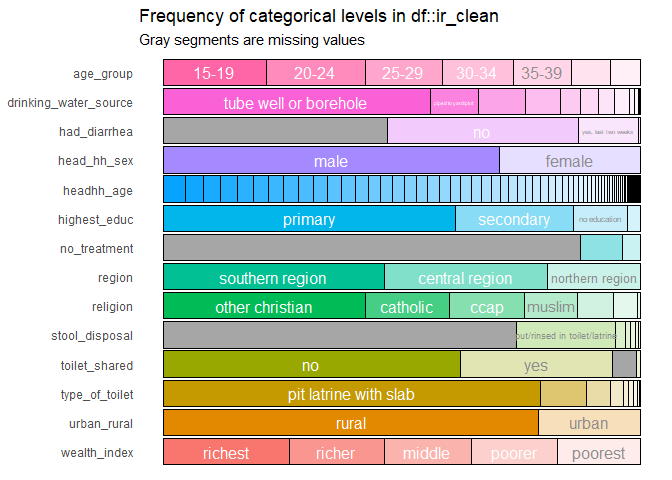

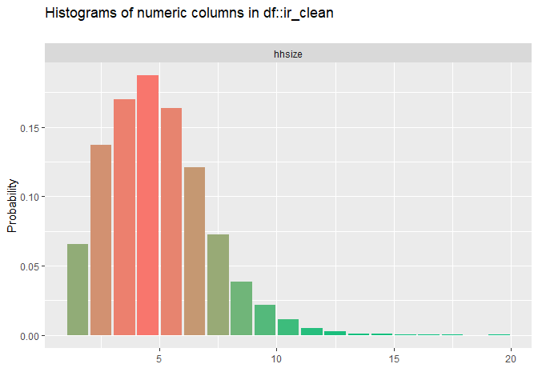

## Selecting and renaming variables and creating a subset of the data.

We have seen from previous summaries that some of our variables have alot of categories, which can be combined or removed e.g. **NAs** and **dont know** so that our visualisations makes sense and are not clouded. we will use *mutate*, *case_when*, *filter* and *group_by* R verbs to acchive this task.

## Data Visualisations using ggplot

### Relationship between household size and drinking water source

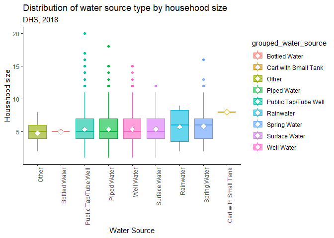

### Diarrhea distribution by household size and residential type

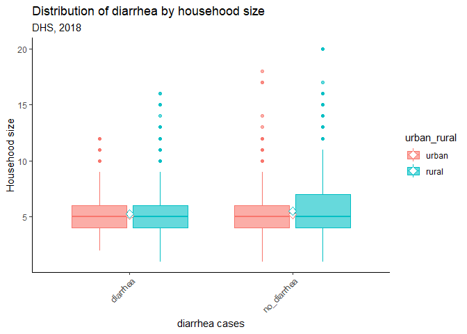

### Diarrhea cases by resdential type

Looking at the table below, See that more cases are observed in the rural areas than in the urban areas. this can be probably due to lack of proper water sources, poor toilets and other factors associated with rural areas.

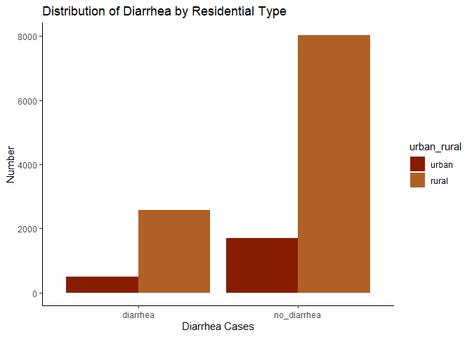

### Distribution ofdairrhea by stool disposal

looking at diarrhea by stool disposal, we see that highest number of diarrhea cases are happening to people put/in latrines followed by those disposing into drain or ditch.

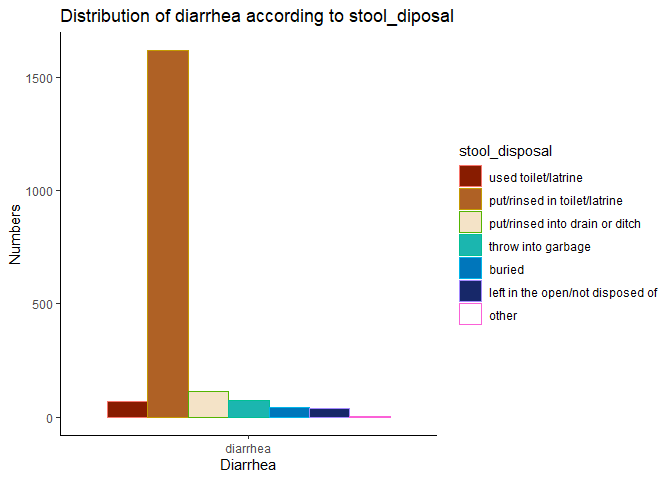

### Distribution of diarrhea by toilet type

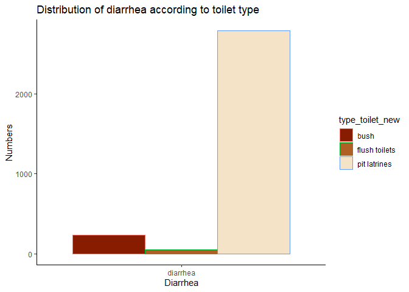

looking at the data above, we see that people with pit latrines are experiencing a lot of diarrhea followed by bush defecation. flush toilets people are the least people to be affected by diarrhea.